# Math 421 - Midterm

## III. Predictive Models

Continue with the data from part I. Make sure you do not have any missing values in the data. Use the follows as the target and input variables:

*Target Variable*: Create the target variable taking value of

- `low` if the total charge of a patient (`tot`) is smaller than the median of the total charge, and
- `high` otherwise.

*Input Variables*:

- “age”,“sex”,“raceethn”,“provider”,“moa”,“mod”,“admtype”,“campus”, ‘los’
1. Use `filter` function to filter out rows where `raceethn==''` or `admtype==''`. Make sure all the categorical variables are factor, numeric variables are numeric. Set Training : Testing Split = 10 : 90

```r
df <- read_csv('midterm.csv')
df <- df %>% filter(raceethn!='',admtype!='')
df$tot2 <- ifelse(df$tot<median(df$tot),'low','high')
```

```r
library(caret)
library(mlbench)
library(rlang)
library(lubridate)
library(rpart)

df <- df %>% mutate(target=as.factor(tot2),
                    age=as.numeric(age),
                    sex=as.factor(sex),
                    raceethn=as.factor(raceethn),
                    provider=as.factor(provider),
                    moa=as.factor(moa),
                    mod=as.factor(mod),
                    admtype=as.factor(admtype),
                    campus=as.factor(campus),
                    los=as.numeric(los))
df <- df %>% select(target,age,sex,raceethn,provider,moa,mod,admtype,campus, los)

set.seed(2020)
splitIndex <- createDataPartition(df$target, p = .10,
                                  list = FALSE)
df_train <- df[ splitIndex,]
df_test <- df[-splitIndex,]
```

2. Train a decision tree using `rpart`. Plot the decision tree. Plot the variable importance ranked by the tree.

[figure not shown]

```r
model1 <- rpart(target ~ ., data = df_train,
                 control = rpart.control(maxdepth = 3))
library(rattle)
fancyRpartPlot(model1)
```

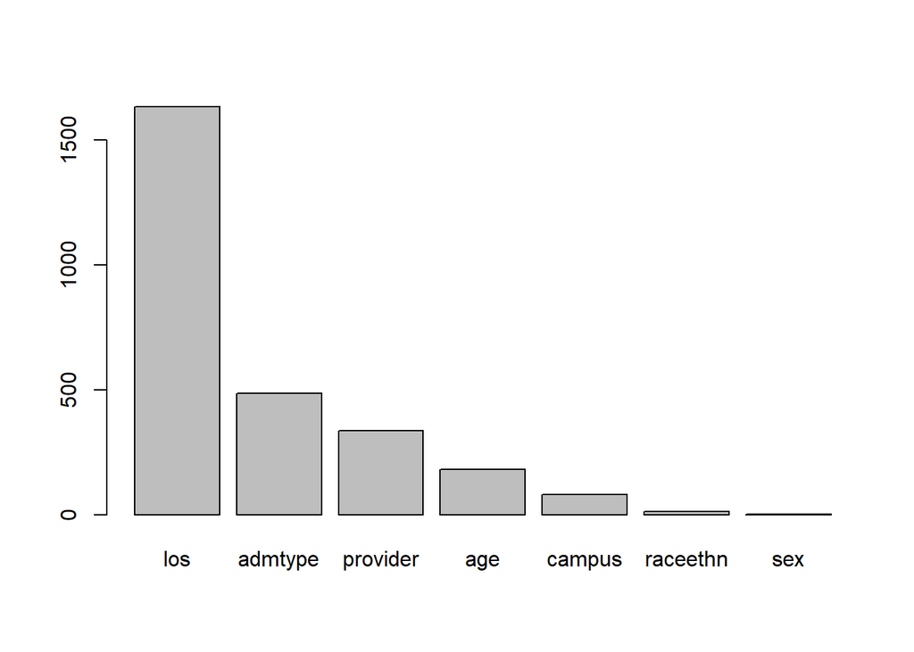

```r
barplot(model1$variable.importance)
```

3. Using caret for this question. Set `Training Control` to be: Use Cross-Validation of 5 folds across all models. Train & tune at least 2 different models (i.e. two different values for `method=` in the train function of caret). Plot the hyper-parameter tuning plots for each model.

```r
trControl = trainControl(method = "cv",
                         number = 5)
tuneGrid =  expand.grid(interaction.depth = c(1, 5, 9),
                        n.trees = (1:30)*50,
                        shrinkage = 0.1,
                        n.minobsinnode = 20)
gbm <- train(target~., data=df_train,
                    method =  "gbm",
                    trControl = trControl,
                    tuneGrid = tuneGrid)
```

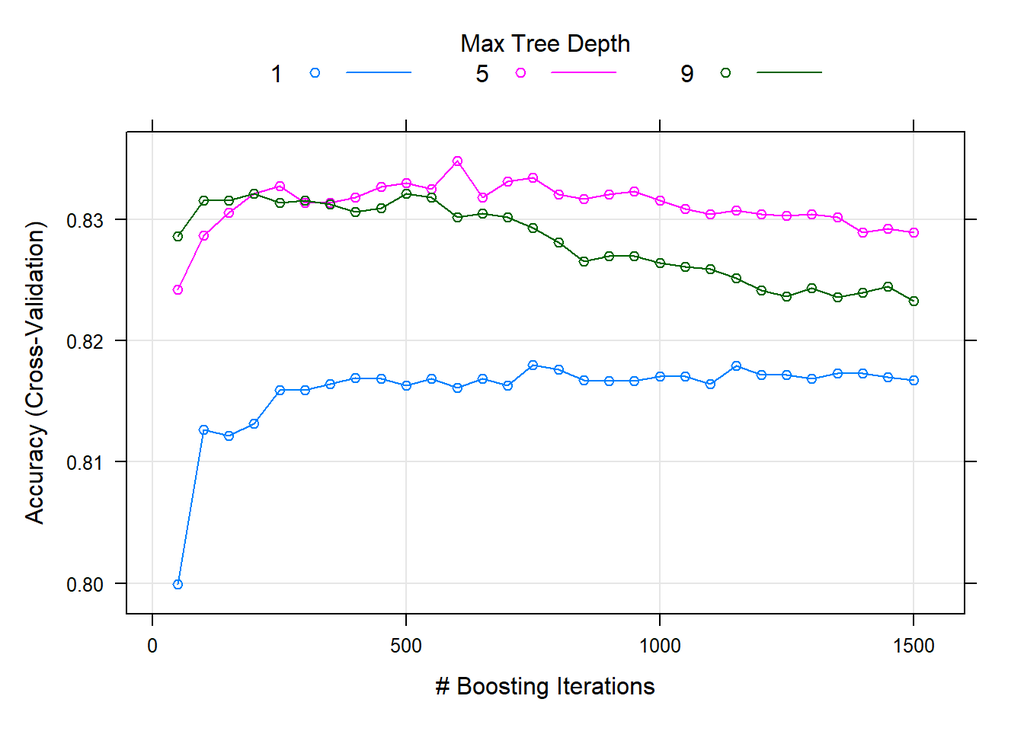

```r
plot(gbm)
```

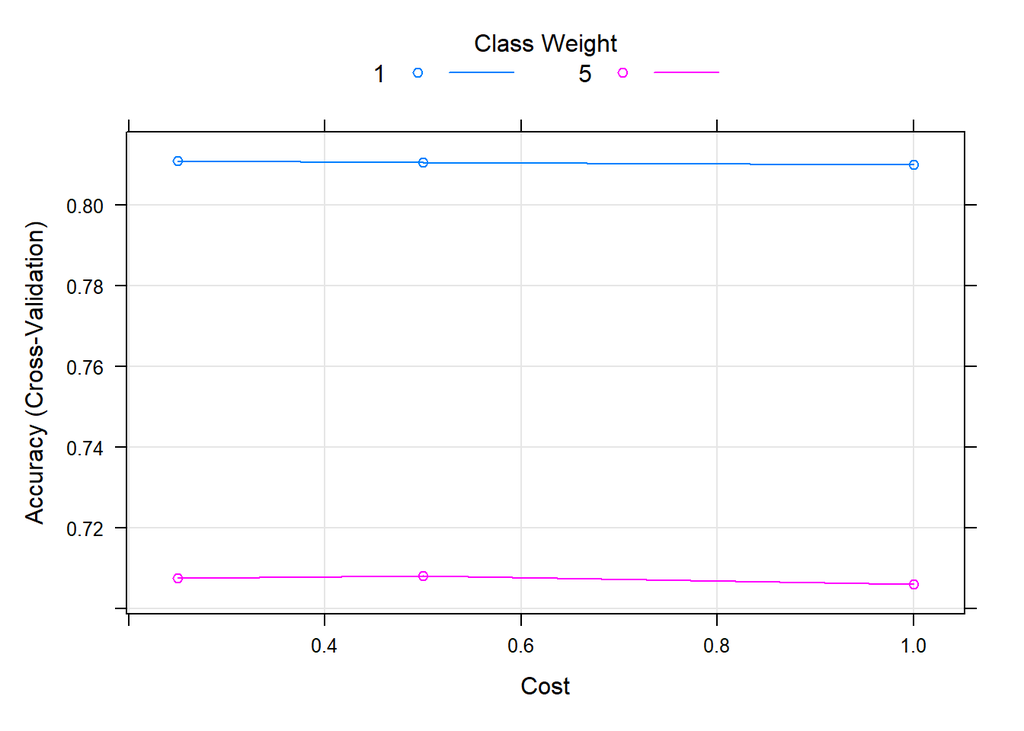

```r
tuneGrid = expand.grid(cost = c(.25, .5, 1), weight = c(1, 5))
linear_weights <- train(target~., data=df_train,
                    method =  "svmLinearWeights",
                    trControl = trControl,
                    tuneGrid = tuneGrid)
plot(linear_weights)
```

4. Plot the comparison of the models in 3.

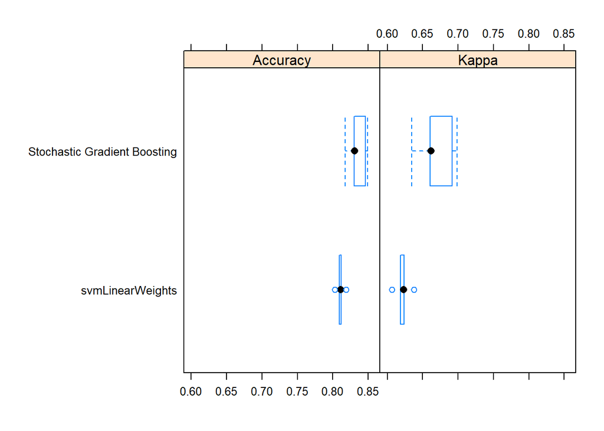

```r
results <- resamples(list('Stochastic Gradient Boosting' = gbm,
                          "svmLinearWeights"= linear_weights))
bwplot(results)
```

5. What is your final selection for the model? Test the accuracy of your final model on the test data.

```r
pred <- predict(gbm, df_test)
cm <- confusionMatrix(data = pred, reference = df_test$target)
cm$overall[1]
```

```
##  Accuracy
## 0.8355972
```

The stochastic Gradient Boosting was the best accuracy

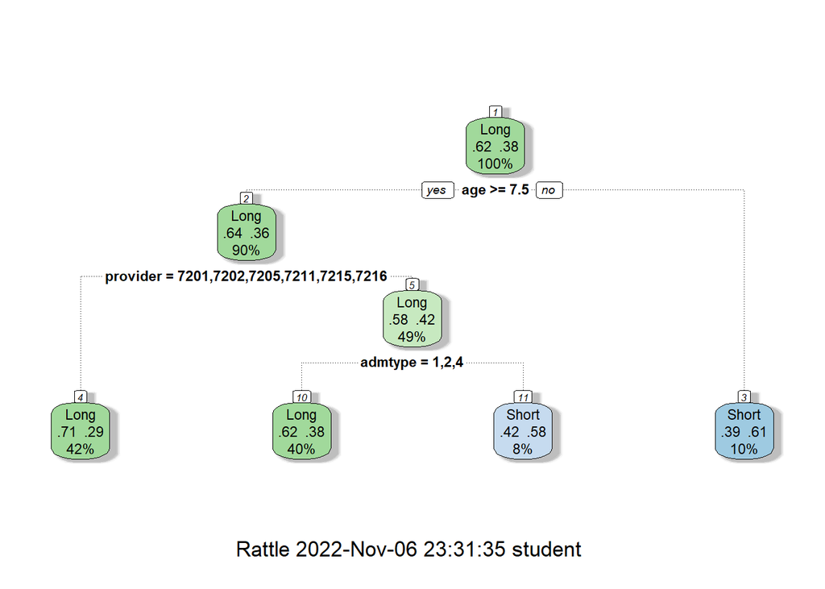

```r
library(caret)
library(mlbench)
library(rlang)
library(lubridate)
library(rpart)
df1 <- read_csv('midterm.csv')
df1 <- df1 %>% filter(raceethn!='',admtype!='')
df1$los2 <- ifelse(df1$los<median(df1$los),'Short','Long')

df1 <- df1 %>% mutate(target = as.factor(los2),
                    age = as.numeric(age),
                    sex = as.factor(sex),
                    raceethn = as.factor(raceethn),
                    provider = as.factor(provider),
                    moa = as.factor(moa),
                    admtype = as.factor(admtype),
                    campus = as.factor(campus))

df1 <- df1 %>% select(target,age,sex,raceethn,provider,moa,admtype,campus)

set.seed(2020)
splitIndex1 <- createDataPartition(df1$target, p = .10,
                                  list = FALSE)
df_train1 <- df1[ splitIndex1,]
df_test1 <- df1[-splitIndex1,]

model2 <- rpart(target ~ ., data = df_train1,
                 control = rpart.control(maxdepth = 3))
library(rattle)
fancyRpartPlot(model2)
```

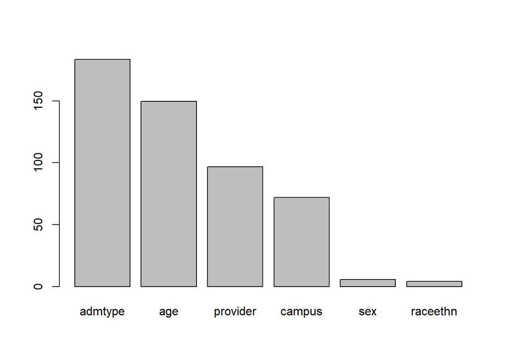

```r
barplot(model2$variable.importance)
```

```r
trControl = trainControl(method = "cv",
                         number = 5)
tuneGrid =  expand.grid(interaction.depth = c(1, 5, 9),
                        n.trees = (1:30)*50,
                        shrinkage = 0.1,
                        n.minobsinnode = 20)
gbm <- train(target~., data=df_train1,
                    method =  "gbm",
                    trControl = trControl,
                    tuneGrid = tuneGrid)
```

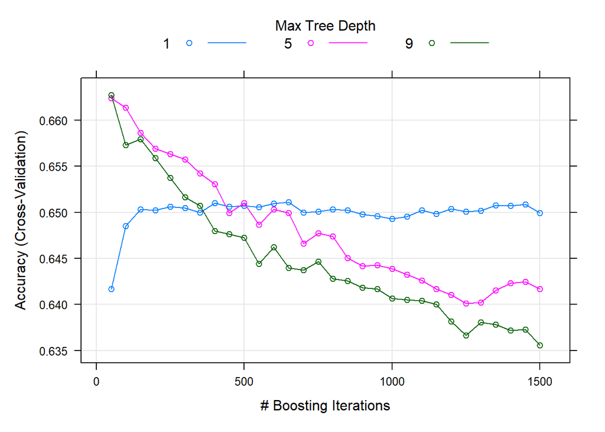

```r
plot(gbm)
```

```r
colSums(is.na(df1))
```

```
##   target      age      sex raceethn provider      moa  admtype   campus
##        0        0        0        0        0        0        0        0
```

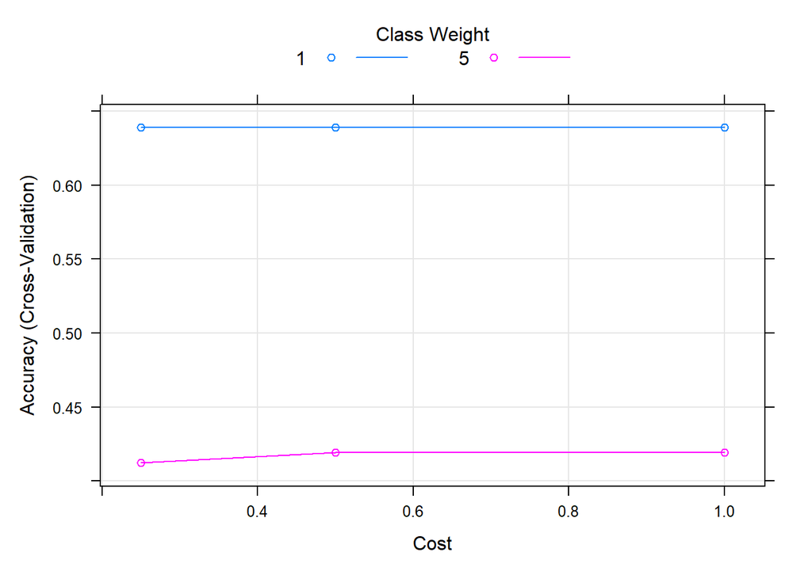

```r
trControl = trainControl(method = "cv",
                         number = 5)
tuneGrid = expand.grid(cost = c(.25, .5, 1), weight = c(1, 5))
linear_weights <- train(target~., data=df_train1,
                    method =  "svmLinearWeights",
                    trControl = trControl,
                    tuneGrid = tuneGrid)
plot(linear_weights)
```

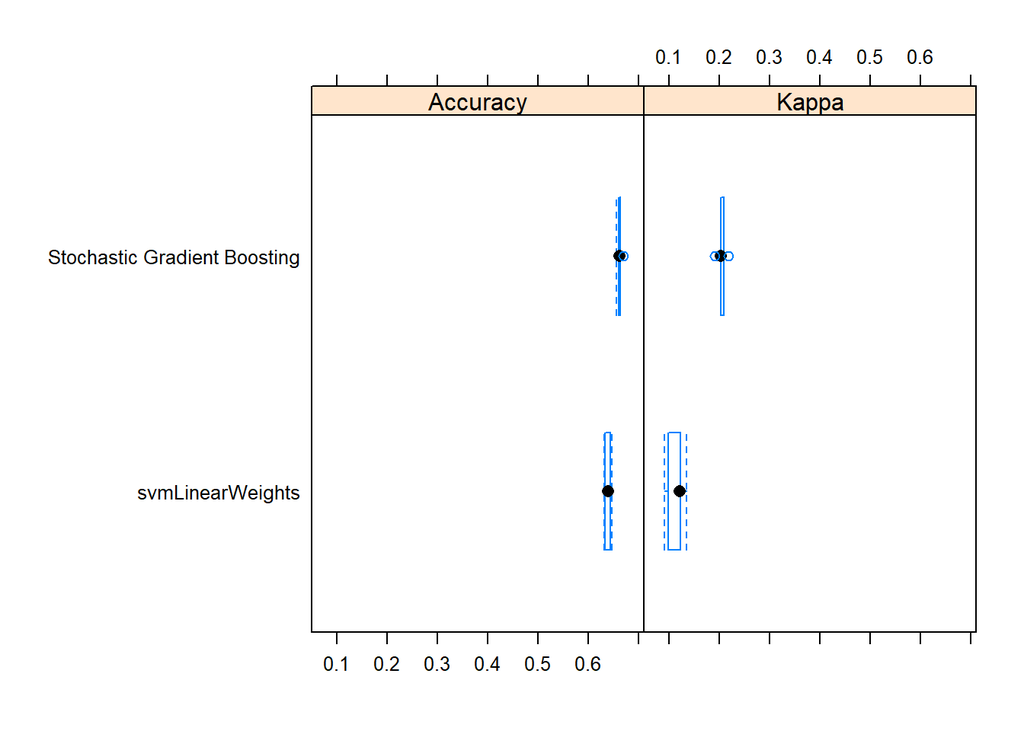

```r
results <- resamples(list('Stochastic Gradient Boosting' = gbm,
                          "svmLinearWeights"= linear_weights))
bwplot(results)
```

7. Write a paragraph to summarize the section and give your comments on the results.

In this section I created predictive models that would help predict certain variables. The first model was the total charge variable the next variable was the lenght of stay. I chose the Stochastic Gradient boosting tree and the SVM linear weights.